# LAGFF 2017

Nicholas Wisniewski

June 11, 2017

The [Los Angeles Greek Film Festival](http://lagff.org/) (LAGFF) presents an Audience Choice award to films based on the ranking of votes. The voting is a 5-star range system, where audience members can give a film an integer score between 1 and 5. An authority score is then used to rank the films. Below are the results for 2017.

# Results

We ranked 3 TYPEs of films: Documentary (D), Feature (F), and Short (S); each is shown in a different color. The average vote is shown in the column labeled AVG, The number of total votes is shown in the column labeled VOTES. The authority score is shown in the column labeled AUTHORITY, and is used to determine the ranking. Note: the rankings within a subgroup of films may be slightly different than the order in the overall rankings (see algorithm).

## Overall

Overall Rankings

|  | FILM | TYPE | VOTES | AVG | AUTHORITY |
| --- | --- | --- | --- | --- | --- |
| 1 | OTHER ME | F | 84 | 4.762 | 1.000 |
| 2 | VASSILLIS THEOCHARAKIS | D | 26 | 4.769 | 0.992 |
| 3 | FROZEN AMBROSIA | D | 52 | 4.731 | 0.988 |
| 4 | SANDY BEACH | S | 13 | 4.769 | 0.986 |
| 5 | BEAUTIFUL DAY | S | 81 | 4.667 | 0.968 |
| 6 | PATRIARCH’S ROOM | D | 31 | 4.677 | 0.963 |
| 7 | XENITIA | D | 29 | 4.655 | 0.962 |
| 8 | BOY ON THE BRIDGE | F | 57 | 4.632 | 0.951 |
| 9 | MEMORIES OF A DOLL | S | 74 | 4.622 | 0.948 |
| 10 | SWING AWAY | F | 120 | 4.592 | 0.934 |
| 11 | ROZA OF SMYRNA | F | 82 | 4.573 | 0.925 |
| 12 | TRUE BLUE | S | 31 | 4.548 | 0.909 |
| 13 | AMERIKA SQUARE | F | 136 | 4.537 | 0.905 |
| 14 | BLISS | F | 10 | 4.500 | 0.882 |
| 15 | LARRY LEVIS, AMERICAN POET | D | 21 | 4.476 | 0.871 |
| 16 | TRUST NO ONE | S | 45 | 4.467 | 0.867 |
| 17 | PLAY | S | 41 | 4.415 | 0.839 |
| 18 | SMAC | F | 17 | 4.353 | 0.807 |
| 19 | MINNIE | S | 86 | 4.337 | 0.799 |
| 20 | TIM OF THE JUNGLE | S | 56 | 4.339 | 0.799 |
| 21 | REFUGEE PASSAGE | D | 12 | 4.333 | 0.794 |
| 22 | WITH THE HOES | D | 14 | 4.214 | 0.725 |
| 23 | MONICA | D | 20 | 4.200 | 0.722 |
| 24 | HELGA | S | 30 | 4.167 | 0.702 |
| 25 | ETHNOPHOBIA | S | 50 | 4.120 | 0.680 |
| 26 | XAMOU | F | 45 | 4.111 | 0.675 |
| 27 | THE GREEK | S | 41 | 4.024 | 0.625 |
| 28 | PARK | F | 16 | 3.938 | 0.570 |
| 29 | OUR MARIA CALLAS | D | 56 | 3.911 | 0.559 |
| 30 | LINES | F | 30 | 3.900 | 0.553 |
| 31 | MARY’S LULLABY | S | 9 | 3.889 | 0.540 |
| 32 | UMMI | S | 14 | 3.786 | 0.480 |
| 33 | LETTERS FROM ATHENS | D | 21 | 3.762 | 0.467 |
| 34 | LIMBO | S | 25 | 3.720 | 0.442 |
| 35 | HINGE | S | 40 | 3.700 | 0.432 |
| 36 | BALLROOM BOYS | S | 15 | 3.667 | 0.409 |
| 37 | MADE YOUR BED | S | 41 | 3.610 | 0.377 |
| 38 | NIPENTHES | S | 27 | 3.444 | 0.271 |
| 39 | LAUGHTER | S | 39 | 3.436 | 0.265 |
| 40 | FROG | S | 35 | 3.429 | 0.262 |
| 41 | FOX | S | 14 | 3.357 | 0.239 |
| 42 | VITHISMA | S | 36 | 3.389 | 0.235 |
| 43 | SEEDS OF CHANGE | S | 41 | 3.341 | 0.209 |
| 44 | AFTERLOV | F | 31 | 3.323 | 0.202 |
| 45 | CUBE | S | 42 | 3.262 | 0.151 |
| 46 | SON OF SOFIA | F | 220 | 3.255 | 0.144 |
| 47 | STONE | S | 36 | 3.083 | 0.069 |
| 48 | SCREAM | S | 29 | 2.966 | 0.053 |

## Feature Films

Feature Film Rankings

|  | FILM | TYPE | VOTES | AVG | AUTHORITY |
| --- | --- | --- | --- | --- | --- |
| 1 | OTHER ME | F | 84 | 4.762 | 1.000 |
| 2 | BOY ON THE BRIDGE | F | 57 | 4.632 | 0.903 |
| 3 | SWING AWAY | F | 120 | 4.592 | 0.868 |
| 4 | ROZA OF SMYRNA | F | 82 | 4.573 | 0.846 |
| 5 | AMERIKA SQUARE | F | 136 | 4.537 | 0.801 |
| 6 | BLISS | F | 10 | 4.500 | 0.775 |
| 7 | SMAC | F | 17 | 4.353 | 0.659 |
| 8 | XAMOU | F | 45 | 4.111 | 0.486 |
| 9 | PARK | F | 16 | 3.938 | 0.395 |
| 10 | LINES | F | 30 | 3.900 | 0.360 |
| 11 | AFTERLOV | F | 31 | 3.323 | 0.098 |
| 12 | SON OF SOFIA | F | 220 | 3.255 | 0.055 |

## Documentaries

Documentary Rankings

|  | FILM | TYPE | VOTES | AVG | AUTHORITY |
| --- | --- | --- | --- | --- | --- |
| 1 | VASSILLIS THEOCHARAKIS | D | 26 | 4.769 | 1.000 |
| 2 | FROZEN AMBROSIA | D | 52 | 4.731 | 0.978 |
| 3 | PATRIARCH’S ROOM | D | 31 | 4.677 | 0.921 |
| 4 | XENITIA | D | 29 | 4.655 | 0.910 |
| 5 | LARRY LEVIS, AMERICAN POET | D | 21 | 4.476 | 0.728 |
| 6 | REFUGEE PASSAGE | D | 12 | 4.333 | 0.586 |
| 7 | WITH THE HOES | D | 14 | 4.214 | 0.470 |
| 8 | MONICA | D | 20 | 4.200 | 0.458 |
| 9 | OUR MARIA CALLAS | D | 56 | 3.911 | 0.178 |
| 10 | LETTERS FROM ATHENS | D | 21 | 3.762 | 0.075 |

## Shorts

Short Film Rankings

|  | FILM | TYPE | VOTES | AVG | AUTHORITY |
| --- | --- | --- | --- | --- | --- |
| 1 | SANDY BEACH | S | 13 | 4.769 | 1.000 |
| 2 | BEAUTIFUL DAY | S | 81 | 4.667 | 0.994 |
| 3 | MEMORIES OF A DOLL | S | 74 | 4.622 | 0.986 |
| 4 | TRUE BLUE | S | 31 | 4.548 | 0.967 |
| 5 | TRUST NO ONE | S | 45 | 4.467 | 0.942 |
| 6 | PLAY | S | 41 | 4.415 | 0.926 |
| 7 | MINNIE | S | 86 | 4.337 | 0.902 |
| 8 | TIM OF THE JUNGLE | S | 56 | 4.339 | 0.900 |
| 9 | HELGA | S | 30 | 4.167 | 0.825 |
| 10 | ETHNOPHOBIA | S | 50 | 4.120 | 0.815 |
| 11 | THE GREEK | S | 41 | 4.024 | 0.772 |
| 12 | MARY’S LULLABY | S | 9 | 3.889 | 0.680 |
| 13 | UMMI | S | 14 | 3.786 | 0.627 |
| 14 | LIMBO | S | 25 | 3.720 | 0.583 |
| 15 | HINGE | S | 40 | 3.700 | 0.575 |
| 16 | BALLROOM BOYS | S | 15 | 3.667 | 0.543 |
| 17 | MADE YOUR BED | S | 41 | 3.610 | 0.512 |
| 18 | NIPENTHES | S | 27 | 3.444 | 0.372 |
| 19 | LAUGHTER | S | 39 | 3.436 | 0.365 |
| 20 | FROG | S | 35 | 3.429 | 0.361 |
| 21 | VITHISMA | S | 36 | 3.389 | 0.324 |
| 22 | FOX | S | 14 | 3.357 | 0.321 |
| 23 | SEEDS OF CHANGE | S | 41 | 3.341 | 0.289 |
| 24 | CUBE | S | 42 | 3.262 | 0.211 |
| 25 | STONE | S | 36 | 3.083 | 0.100 |
| 26 | SCREAM | S | 29 | 2.966 | 0.075 |

# Visualization

We visualized the ranking system using a forest plot. The average vote is depicted by a square and a 95% confidence interval. The number of total votes is depicted by the size of the squares. The authority score is used to determine the ranking

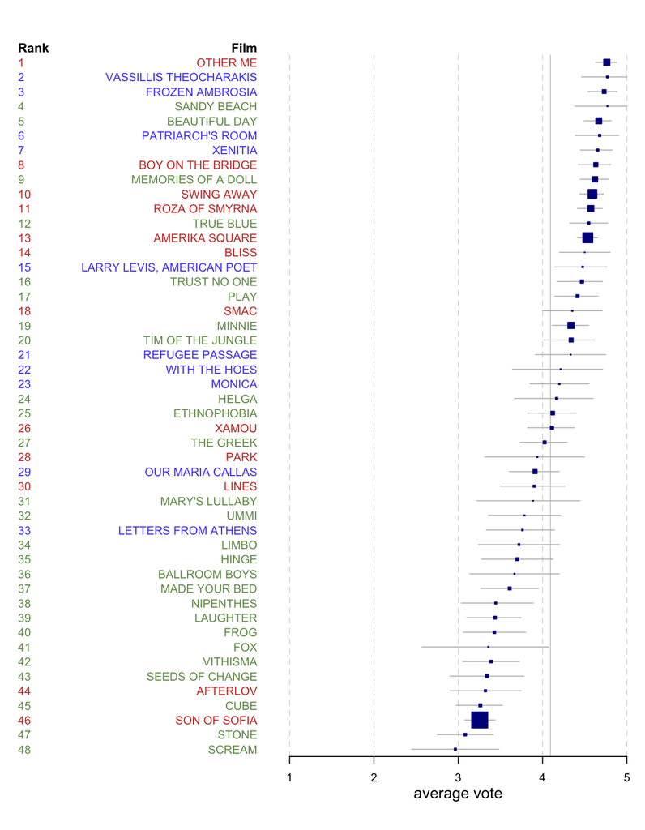

# About the Ranking Algorithm

The LAGFF ranking algorithm bootstraps the probability that the average score $\mu_i$ of film $i$ is truly greater than any other film $j$, by resampling the votes to simulate the universe of all possible rankings. This matrix of probabilities $p_{ij}=p(\mu_j \gt \mu_i)$ is then treated as a weighted directed graph, and the [authority score](http://citeseerx.ist.psu.edu/viewdoc/summary?doi=10.1.1.418.3908) $\text{eig}_1(p^Tp)$ is used to rank the films, in a way similar to Google *page-rank*.

### Why this algorithm?

This ranking system was adopted by LAGFF to address a problem in estimating ranks introduced by the wide range of audience sizes at a film festival. Specifically, ranking based on naive ordering the mean scores can produce undesirable results. For example, a high scoring film that many people came to see (opening/closing night) can sometimes be beaten by a film that very few people came to see, but which also scored highly, only because of the increased sampling error in the small group. The LAGFF algorithm addresses this problem by using resampling to weigh the relative superiority of each film to every other, which can then produce more meaningful rankings using graph theory.

### How are the results different?

This method is asymptotically equivalent to the naive ordering – in the limit where all audience sizes are large, they give the same results. However, when both large and small audiences are present, this method tends to favor scores from larger audiences, which is desirable. However, as a side effect, the relative ranking of two particular films becomes dependent on their relative rankings with all of the other films. For this reason, the ranking within a subgroup of films may end up slightly differing from their relative ranking in the context of all the films.

# References

[[1](http://citeseerx.ist.psu.edu/viewdoc/summary?doi=10.1.1.418.3908)] Kleinberg, J. M. (1999). Authoritative sources in a hyperlinked environment. *Journal of the ACM (JACM)*, 46(5), 604-632.